# Collinearity Diagnostics, Model Fit & Variable Contribution

# Collinearity Diagnostics

Collinearity implies two variables are near perfect linear combinations of one another. Multicollinearity involves more than two variables. In the presence of multicollinearity, regression estimates are unstable and have high standard errors.

```r
model <- lm(mpg ~ disp + hp + wt + qsec, data = mtcars)
ols_coll_diag(model)
```

```
Tolerance and Variance Inflation Factor
---------------------------------------
```

| Variables | Tolerance | VIF |
| --- | --- | --- |
| disp | 0.1252279 | 7.985439 |
| hp | 0.1935450 | 5.166758 |
| wt | 0.1445726 | 6.916942 |
| qsec | 0.3191708 | 3.133119 |

```
Eigenvalue and Condition Index
------------------------------
```

| Eigenvalue | Condition Index | intercept | disp | hp | wt | qsec |
| --- | --- | --- | --- | --- | --- | --- |
| 4.721487187 | 1.000000 | 0.000123237 | 0.001132468 | 0.001413094 | 0.0005253393 | 0.0001277169 |
| 0.216562203 | 4.669260 | 0.002617424 | 0.036811051 | 0.027751289 | 0.0002096014 | 0.0046789491 |
| 0.050416837 | 9.677242 | 0.001656551 | 0.120881424 | 0.392366164 | 0.0377028008 | 0.0001952599 |
| 0.010104757 | 21.616057 | 0.025805998 | 0.777260487 | 0.059594623 | 0.7017528428 | 0.0024577686 |
| 0.001429017 | 57.480524 | 0.969796790 | 0.063914571 | 0.518874831 | 0.2598094157 | 0.9925403056 |

## Variance Inflation Factors

They measure the inflation in the variances of the parameter estimates due to collinearities that exist among the featuers. It is a measure of how much the variance of the regression coefficient $\beta_k$ is inflated by the existence of correlation among the features in the model.

A VIF of 1 means that there is no correlation. The general rule of thumb is that VIFs exceeding 4 warrant further investigation. The steps to calculate VIF are: * Regress the $k^{th}$ feature on rest of the features in the model. * Compute $R_k^2$

$$VIF = \frac{1}{1-R_k^2} = \frac{1}{Tolerance}$$

```r
model = lm(mpg ~ disp + hp + wt + qsec, data = mtcars)
ols_vif_tol(model)
```

| Variables | Tolerance | VIF |
| --- | --- | --- |
| disp | 0.1252279 | 7.985439 |
| hp | 0.1935450 | 5.166758 |
| wt | 0.1445726 | 6.916942 |
| qsec | 0.3191708 | 3.133119 |

## Condition Index

Most multivariate statistical approaches involve decomposing a correlation matrix into linear combinations of variables. The linear combinations are chosen so that the first combination has the largest possible variance (subject to some restrictions we won’t discuss), the second combination has the next largest variance, subject to being uncorrelated with the first, the third has the largest possible variance, subject to being uncorrelated with the first and second, and so forth. The variance of each of these linear combinations is called an eigenvalue. Collinearity is spotted by finding 2 or more variables that have large proportions of variance (.50 or more) that correspond to large condition indices. A rule of thumb is to label as large those condition indices in the range of 30 or larger.

```r
model <- lm(mpg ~ disp + hp + wt + qsec, data = mtcars)
ols_eigen_cindex(model)
```

| Eigenvalue | Condition Index | intercept | disp | hp | wt | qsec |
| --- | --- | --- | --- | --- | --- | --- |
| 4.721487187 | 1.000000 | 0.000123237 | 0.001132468 | 0.001413094 | 0.0005253393 | 0.0001277169 |
| 0.216562203 | 4.669260 | 0.002617424 | 0.036811051 | 0.027751289 | 0.0002096014 | 0.0046789491 |
| 0.050416837 | 9.677242 | 0.001656551 | 0.120881424 | 0.392366164 | 0.0377028008 | 0.0001952599 |
| 0.010104757 | 21.616057 | 0.025805998 | 0.777260487 | 0.059594623 | 0.7017528428 | 0.0024577686 |
| 0.001429017 | 57.480524 | 0.969796790 | 0.063914571 | 0.518874831 | 0.2598094157 | 0.9925403056 |

# Model Fit Assessment

## Residual Fit Spread Plot

Plot to detect non-linearity, influential observations and outliers. Consists of side-by-side quantile plots of the centered fit and the residuals.

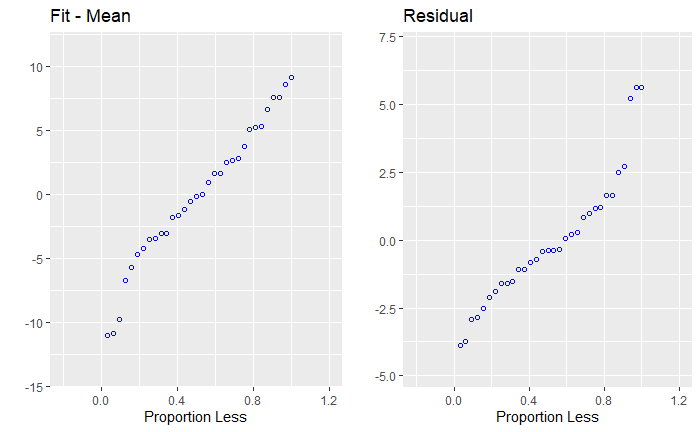

```r
model <- lm(mpg ~ disp + hp + wt + qsec, data = mtcars)
ols_plot_resid_fit_spread(model)
```

## Part & Partial Correlations

### Correlations

How much each feature uniquely contributes to $R^2$.

### Zero order

Pearson correlation coefficient between the dependent variable and the features.

### Part

Unique contribution of feature. How much the $R^2$ would decrease if the feature was removed from the model.

### Partial

How much of the output variance is estimaited by the feature.

```r
model <- lm(mpg ~ disp + hp + wt + qsec, data = mtcars)
ols_correlations(model)
```

```
               Correlations
-------------------------------------------
Variable    Zero Order    Partial     Part
-------------------------------------------
disp            -0.848      0.048     0.019
hp              -0.776     -0.224    -0.093
wt              -0.868     -0.574    -0.285
qsec             0.419      0.219     0.091
-------------------------------------------
```

## Observed vs Predicted Plot

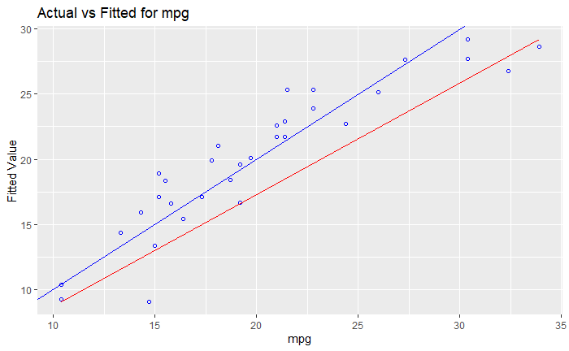

```r
model <- lm(mpg ~ disp + hp + wt + qsec, data = mtcars)
ols_plot_obs_fit(model)
```

## Lack of Fit F Test

The residual sum of squares can be decomposed into 2 components: * Due to lack of fit * Due to random variation

If most of the error is due to lack of fit and not just random error, the model should be discarded and a new model must be built. The test assesses how much of the error in the prediction is due to the lack of model fit.

```r
model <- lm(mpg ~ disp, data = mtcars)
ols_pure_error_anova(model)
```

```
Lack of Fit F Test
-----------------
Response :   mpg
Predictor:   disp

                      Analysis of Variance Table
----------------------------------------------------------------------
                DF     Sum Sq     Mean Sq     F Value        Pr(>F)
----------------------------------------------------------------------
disp             1    808.8885    808.8885    314.0095    1.934413e-17
Residual        30    317.1587    10.57196
 Lack of fit    25    304.2787    12.17115    4.724824      0.04563623
 Pure Error      5       12.88       2.576
----------------------------------------------------------------------
```

## Diagnostics Panel

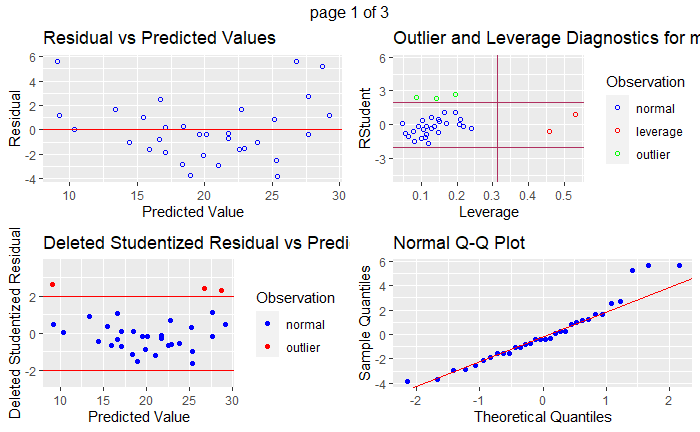

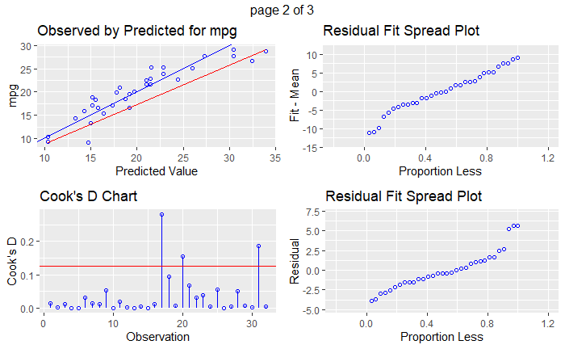

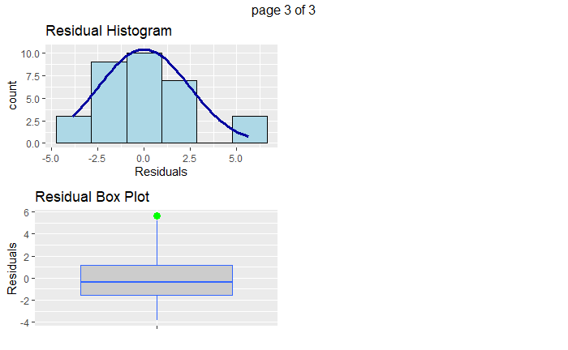

```r
model <- lm(mpg ~ disp + hp + wt + qsec, data = mtcars)
ols_plot_diagnostics(model)
```

# Variable Contributions

## Residual vs Regressor Plots

Graph to determine whether we should add a new predictor to the model already containing other predictors. The residuals from the model is regressed on the new predictor and if the plot shows non random pattern, you should consider adding the new predictor to the model.

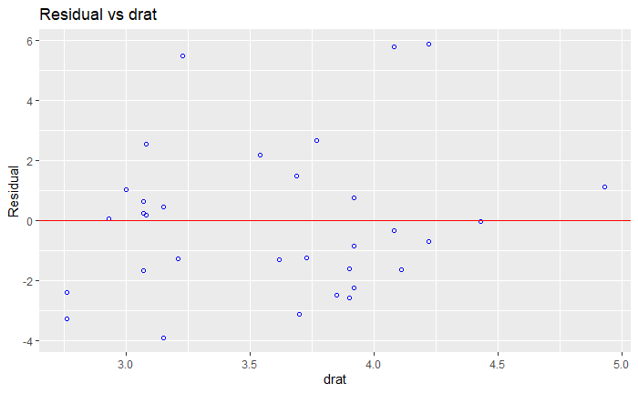

```r
model <- lm(mpg ~ disp + hp + wt, data = mtcars)
ols_plot_resid_regressor(model, 'drat')
```

## Added Variable Plot

Provides information about the marginal importance of a feature X, given the other features already in the model.

Steps to construct an added variable plot: * Regress Y on all features other than X and store the residuals. * Regress X on all the other features in the model. * Construct a scatter plot with the residuals of the previous steps.

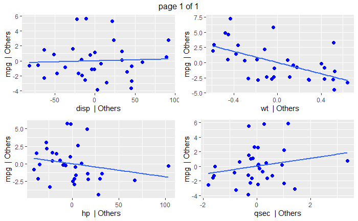

```r
model <- lm(mpg ~ disp + hp + wt + qsec, data = mtcars)
ols_plot_added_variable(model)
```

## Residual Plus Component Plot

Steps to construct the plot: * Regress Y on all features including X. * Multiply $e$ with regression coefficient of X. * Construct plot of $eX$ and $X$.

The residual plus component plot indicates whether any non-linearity is present in the relationship between Y and X and can suggest possible transformations for linearizing the data.

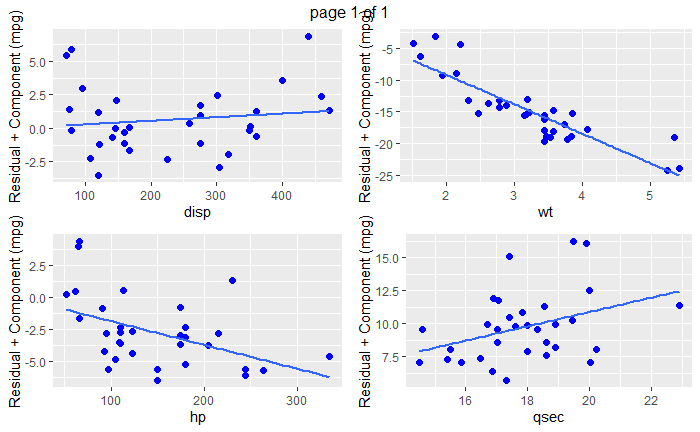

```r
model <- lm(mpg ~ disp + hp + wt + qsec, data = mtcars)
ols_plot_comp_plus_resid(model)
```

# References

https://olsrr.rsquaredacademy.com/articles/regression_diagnostics.html